# Welcome to CRSS 4060/6060 Advanced Topics in Precision Ag!

Spring 2023

Dr. Leo Bastos

## Meet the professors

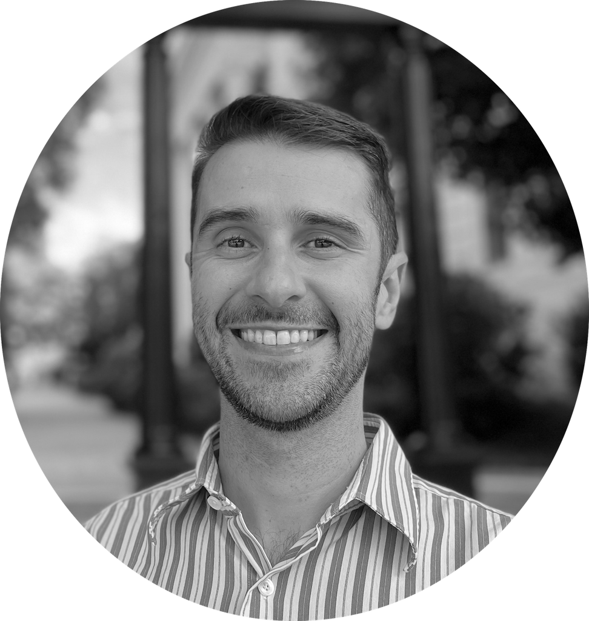

Dr. Leonardo M. Bastos

Assistant Professor  
4101 Miller Plant Sciences Building  
UGA-Athens Campus  
Email: lmbastos@uga.edu

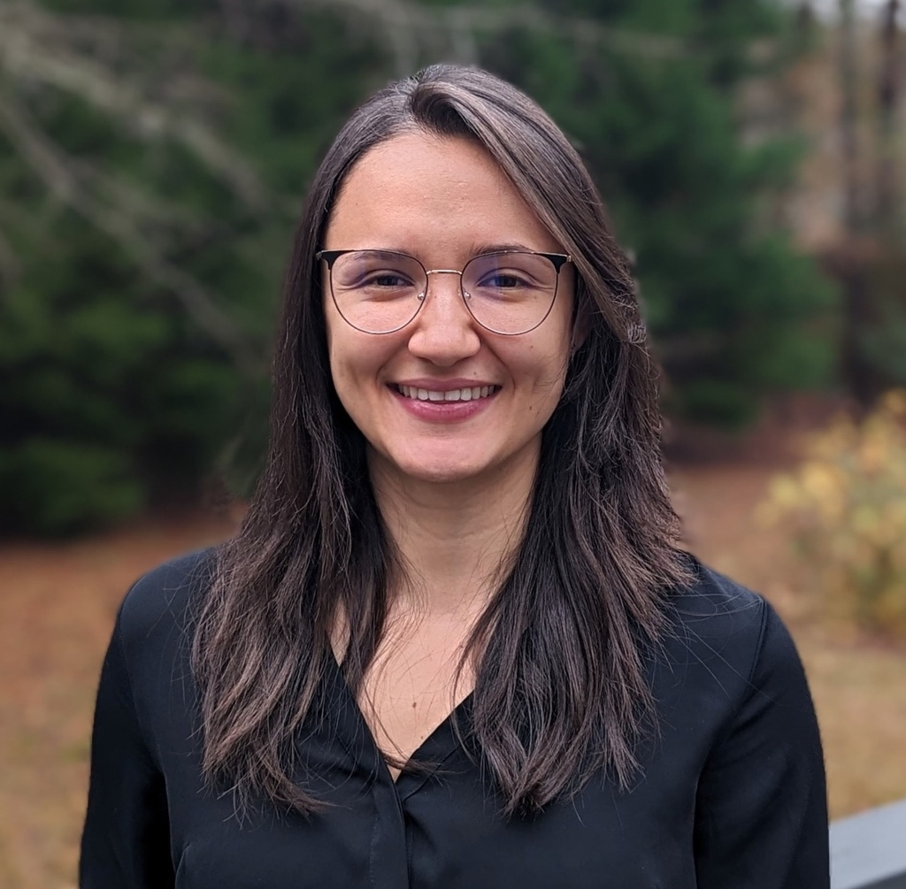

Dr. Lorena Lacerda

Assistant Professor  
4103 Miller Plant Sciences Building UGA-Athens Campus  
Email: llacerda@uga.edu

# Syllabus rundown

Full syllabus can be found [here](https://leombastos.github.io/bastoslab/teaching/2023-ppa/2023-ppa.html#course-syllabus)

## Meeting times and locations

Time:

- **Lectures**: Monday and Friday at 09:10-10:00
- **Labs**: Wednesday at 09:10-11:10

Location:

- **Athens** campus: in person at 1203 3203 Miller
- **Tifton** campus: in person at 601 NESPAL South OR remote
- **Griffin** campus: in person at SLC UGA Computer lab OR remote

Zoom credentials shared via email.

## Course objectives

1. Obtain, process, and use various agricultural geospatial data layers for decision making related to precision agriculture.

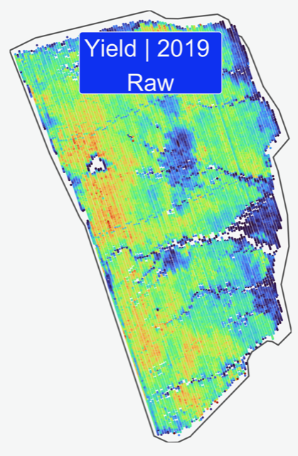

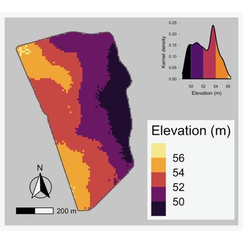

## Course objectives

2. Data types include publicly available (weather, soils, and **satellite remote sensing**), and private data like **yield monitor**, **soil**, and UAV remote sensing).

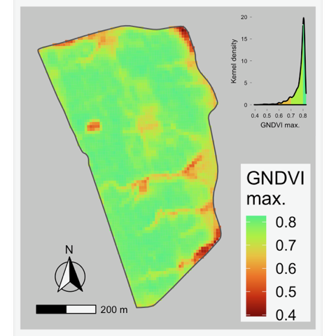

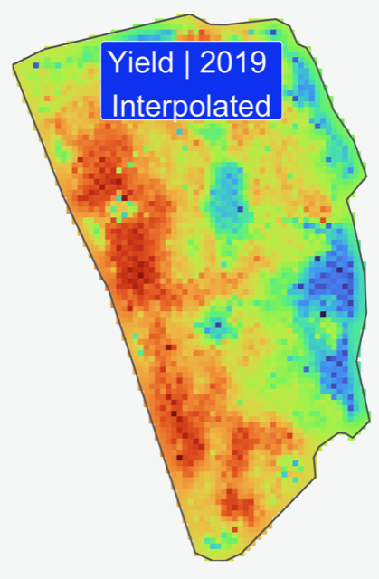

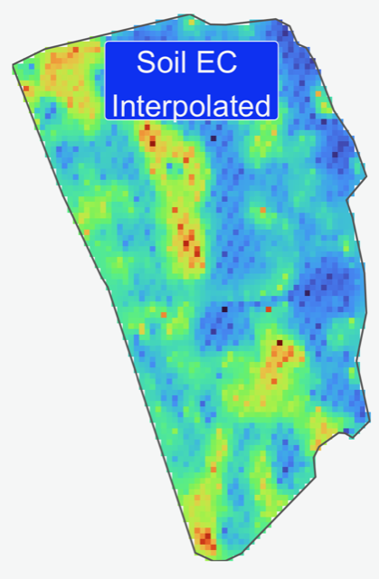

## Course objectives

3. Analytical techniques include creation of management zones, **zone-based and imagery-based variable rate prescription**, **profitability maps**, and use of **satellite remote sensing for crop scouting**.

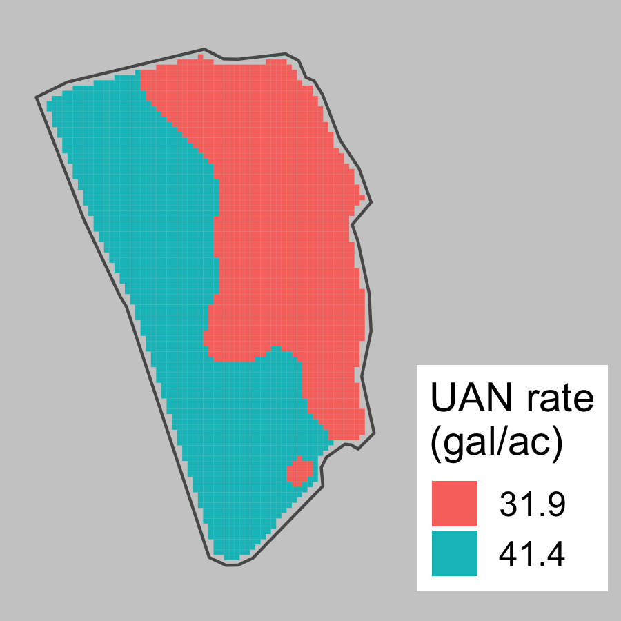

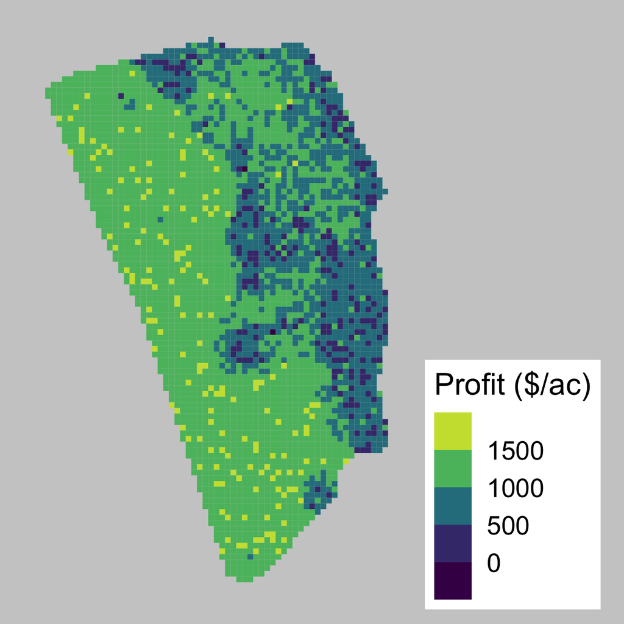

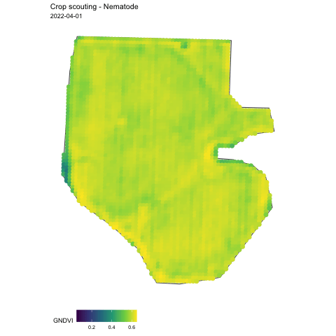

## Course objectives

4. All steps will be conducted utilizing the **R statistical language** to create modern, well documented and reproducible precision agriculture analytical workflows. No previous knowledge in R is required.

[figure not shown]

## Course objectives

For example, from raw yield data to management zone creation

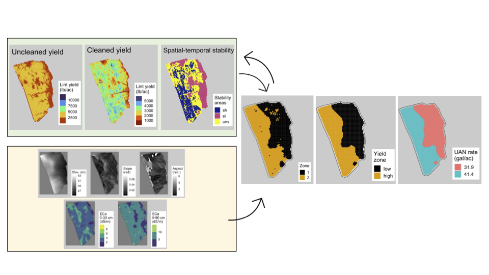

## Course topics

1. Intro to R
2. Using R as a GIS
3. Accessing publicly available geospatial data through R
4. Creating grids for soil sampling
5. Interpolation
6. Yield monitor data processing
7. Terrain data processing
8. Management zones
9. UAV remote sensing
10. Variable rate prescription
11. Profitability maps
12. Satellite remote sensing for crop scouting

All classes will be recorded and further posted on the class YouTube channel.

This should be used as a supporting study tool and make-up for content from missed classes. **Recordings do not replace in-person/remote attendance**.

## Assessment and Grading

| Activity | Grade |
| --- | --- |
| Mini-project: USDA NASS data | 10% |
| Mid-term exam | 10% |
| Homework assignments | 35% |
| In-class quizzes | 15% |
| Final project: from raw data to zone-based variable rate | 20% |
| Class participation | 10% |

## Course website

Important links related to this course:

- [Course website](https://leombastos.github.io/bastoslab/teaching/2023-apa/2023-apa.html)
- [Course GitHub repository](https://github.com/leombastos/2023_AdvPA)
- [Course YouTube channel](https://youtube.com/playlist?list=PLcdv9xoF_6TFzITEruQ1JnP54FdNO4PtI)

## Course website - downloading slides

1. With the slides page open on your browser, push `e` on your keyboard.
2. On your browser, go to `File > Print`.
3. Adjust orientation and pages per sheet if desired.
4. Save as PDF.

## Course website - asking questions

- If your question is related to **difficulties with material/code/assignments**, then post it on our class GitHub page on the `Issues` tab.
- Go to the class [GitHub repository](https://github.com/leombastos/2023_AdvPA) > Click on `Issues` (near top left) > Click on `New issue` (green button) > Give it a descriptive title, leave your comment > Click on `Submit new issue`.
- Let’s try it out: introductions (may need to sign up to GitHub)

## Course website - asking questions

By asking questions on GitHub, other students may be able to help you besides only instructor.

**Helping others on GitHub will count as participation!**

## Attendance policy

Students are expected to attend every class period.

Students on the **Athens campus** must attend class in-person.

If a special circumstance arise (illness, travel, etc.), student absence or remote attendance **must be informed to instructors prior to that class period**.

## Attendance policy

Students are expected to attend every class period.

Students on the **Tifton and Griffin campuses** may attend class in-person on their campuses or remote using the zoom link information.

Student absence **must be informed to instructors prior to that class period**.

## Attendance policy

Students are expected to attend every class period.

Per Board of Regents policy, I reserve the right to drop students from the class roll who **miss more than 5 class periods**. Such students will be given a WF grade.

## Attendance policy

When attending a class remotely via zoom, students are expected to have **cameras on at all times**.

## Technology and software requirements

Students will need to have access to:

- A computer 💻 (to install software, code along with instructors)
- A second screen 📺 (main screen to code along, second screen to watch class if not in person)

If a student does not have access to these resources (personal laptop/desktop and a second screen), please let instructors know to ensure proper accommodations can be made.

## Survey

Please go to the link below and fill this survey:

https://forms.gle/M78MDXLrtXBVUHyt7

Take 5 minutes to answer it.

## Getting ready for next class

To be ready for next class (**Intro to R**), please go to the course main page and follow the link to the `Lab 01 prep` page.

If you have questions or issues, email me **before class**.

We will have limited time to troubleshoot technical problems during next period.

# Thanks, and see you on Wednesday!